# **Zack Loken - OCS 7131 Exercise 8**

#### **1. Find a dataset with a factor that could be considered a random effect.**

##### Winter (October 1 - December 31) surface water area as a response to mean max winter temperature by the categorical effect of wetland type (6 levels) for a portion of Missouri’s Lower Grand River floodplain.

##### Why to consider random effects for this model:

1. Both the individual wetland types and the relationship between surface water area and mean winter max temp can be viewed as a random sample from a probability distribution.
2. The intended scope of inference extends beyond the levels of the factor (wetland type) included in the current analysis to the entire population of a factor.
3. The coefficients of a given factor *could be* modeled to see if there is variation in surface water area across wetland type.
4. There is a lack of statistical independence due to multiple observations from each wetland type over space and time.

```r
library(tidyverse)
library(RColorBrewer)
library(data.table)

# Loading the data
LGRW_SWA <- read.csv("E:/Zack/Google Earth Engine/GEE for Systems Ecology - Spring 2021/Missouri Habitat and Water Classification/SurfaceWaterArea_Annual/LGRW_WetHectares_byYear.csv") # Annual surface water area (SWA): 1984 - 2020

LGRW_TC <- read.csv("E:/Zack/Google Earth Engine/GEE for Systems Ecology - Spring 2021/Missouri Habitat and Water Classification/TerraClim/TerraClim_OctNovDec_LGRW.csv") # Annual TerraClim climate data: 1984 - 2020

# Quick cleanup -- rename the column headers
setnames(LGRW_SWA, skip_absent = TRUE,
         old = c('CoverType', 'Owner', 'Hectares', 'X1984_SWA', 'X1987_SWA', 'X1989_SWA', 'X1990_SWA',
                 'X1991_SWA', 'X1992_SWA', 'X1994_SWA', 'X1996_SWA', 'X1997_SWA', 'X1999_SWA', 'X2001_SWA',
                 'X2004_SWA', 'X2005_SWA', 'X2006_SWA', 'X2010_SWA', 'X2011_SWA', 'X2014_SWA', 'X2015_SWA',
                 'X2016_SWA', 'X2018_SWA', 'X2019_SWA', 'X2020_SWA'),
         new = c('Cover_Type', 'Owner', 'Hectares', '1984', '1987', '1989', '1990', '1991', '1992', '1994',
                 '1996', '1997', '1999', '2001', '2004', '2005', '2006', '2010', '2011', '2014', '2015',
                 '2016', '2018','2019', '2020'))

# Subset to show only wetland cover type classes.
LGRW_SWA_Sub <- subset(LGRW_SWA, Cover_Type == c('Levee', 'Grand River', 'Wetland',
                      'Forest - Riprarian', 'Water Bodies', 'Aquatic'),
                       select = c(1:25))

# Convert wide data frame to narrow format with one column containing year.
narrow.LGRW_SWA_Sub <- pivot_longer(data = LGRW_SWA_Sub,
                          cols = c(4:25),
                          names_to = "Year",
                          values_to = "SWA_Hectares")

# Remove 'Hectares' column from narrow.LGRW_SWA data frame (This column is polygon size)
narrow.LGRW_SWA_Sub2 <- subset(narrow.LGRW_SWA_Sub, select = -Hectares)

# Group by class, then summarize the total surface water area of each class for each year.
LGRW_SWA_Sum <- narrow.LGRW_SWA_Sub2 %>%
                    group_by(Cover_Type, Year) %>%
                    summarise(SWA_sum = sum(SWA_Hectares), n = n())

# Change all 'Forest - Riprarian' values to 'Forest - Riparian'
LGRW_SWA_Sum$Cover_Type[23:44] <- "Forest - Riparian"

# Merge (left join) the LGRW_SWA and LGRW_TC data frames into one df
LGRW_TC$Year <- as.character(LGRW_TC$year)
LGRW <- merge(x = LGRW_SWA_Sum, y = LGRW_TC, by = "Year", all.x = TRUE)

# Log transform SWA_sum and tmmx_cels (mean max winter temp(Oct, Nov, Dec)) to improve model fit
LGRW$l.tmmx_cels <- log(LGRW$tmmx_cels)
LGRW$l.SWA_sum <- log(LGRW$SWA_sum)
```

#### **2. Using the `lme4` library, run a simple model of your data.**

```r
library(lme4)

# Mixed model with fixed slope and random intercept
mix.int<- lmer(l.SWA_sum ~ l.tmmx_cels + (1 | Cover_Type), data = LGRW)
summary(mix.int)
```

```
## Linear mixed model fit by REML ['lmerMod']
## Formula: l.SWA_sum ~ l.tmmx_cels + (1 | Cover_Type)
##    Data: LGRW
##
## REML criterion at convergence: 127
##
## Scaled residuals:
##     Min      1Q  Median      3Q     Max
## -7.2004 -0.3626  0.1845  0.5471  1.4399
##
## Random effects:
##  Groups     Name        Variance Std.Dev.
##  Cover_Type (Intercept) 1.1596   1.0768
##  Residual               0.1213   0.3483
## Number of obs: 132, groups:  Cover_Type, 6
##
## Fixed effects:
##             Estimate Std. Error t value
## (Intercept)   7.2646     0.7664   9.479
## l.tmmx_cels   0.0713     0.2522   0.283
##
## Correlation of Fixed Effects:
##             (Intr)
## l.tmmx_cels -0.818
```

```r
coef(mix.int)$Cover_Type
```

```
##                   (Intercept) l.tmmx_cels
## Aquatic              6.191060  0.07129821
## Forest - Riparian    8.040873  0.07129821
## Grand River          6.971612  0.07129821
## Levee                5.905950  0.07129821
## Water Bodies         7.936040  0.07129821
## Wetland              8.542344  0.07129821
```

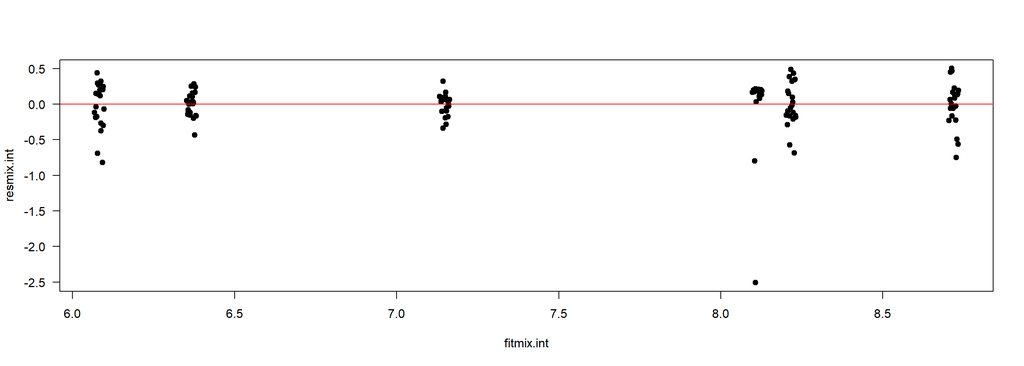

```r
# Plot the residuals as a function of the fitted data.
resmix.int <- resid(mix.int)
fitmix.int <- fitted(mix.int)
plot(resmix.int ~ fitmix.int, pch = 19, las = 1); abline(0, 0, col = "red")
```

```r
# Mixed model with random slope and fixed intercept
mix.sl <- lmer(l.SWA_sum ~ l.tmmx_cels + (0 + l.tmmx_cels | Cover_Type), data = LGRW)
summary(mix.sl)
```

```
## Linear mixed model fit by REML ['lmerMod']
## Formula: l.SWA_sum ~ l.tmmx_cels + (0 + l.tmmx_cels | Cover_Type)
##    Data: LGRW
##
## REML criterion at convergence: 129.3
##
## Scaled residuals:
##     Min      1Q  Median      3Q     Max
## -7.0833 -0.3662  0.1846  0.5596  1.5870
##
## Random effects:
##  Groups     Name        Variance Std.Dev.
##  Cover_Type l.tmmx_cels 0.1868   0.4322
##  Residual               0.1236   0.3515
## Number of obs: 132, groups:  Cover_Type, 6
##
## Fixed effects:
##             Estimate Std. Error t value
## (Intercept)   7.2646     0.6336   11.47
## l.tmmx_cels   0.0713     0.3097    0.23
##
## Correlation of Fixed Effects:
##             (Intr)
## l.tmmx_cels -0.821
```

```r
coef(mix.sl)$Cover_Type
```

```
##                   (Intercept) l.tmmx_cels
## Aquatic              7.264646  -0.3594373
## Forest - Riparian    7.264646   0.3830977
## Grand River          7.264646  -0.0468210
## Levee                7.264646  -0.4743384
## Water Bodies         7.264646   0.3430594
## Wetland              7.264646   0.5822289
```

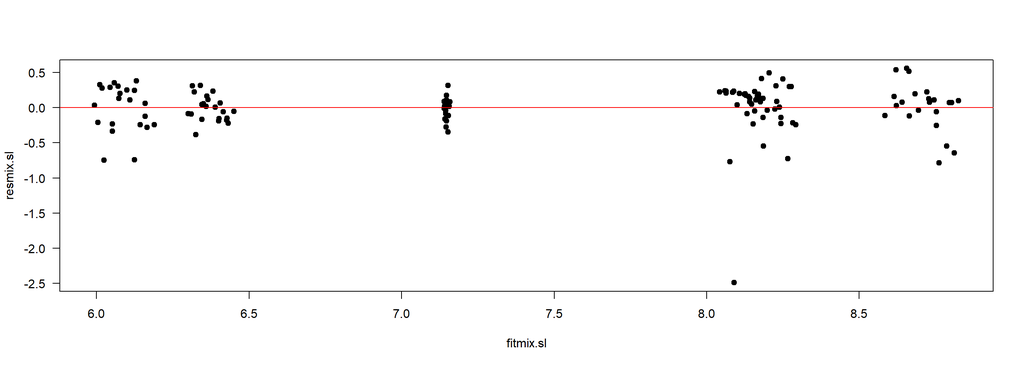

```r
# Plot the residuals as a function of the fitted data.
resmix.sl <- resid(mix.sl)
fitmix.sl <- fitted(mix.sl)
plot(resmix.sl ~ fitmix.sl, pch = 19, las = 1); abline(0, 0, col = "red")
```

```r
# Random effects model with random slope and random intercept
re.mod <- lmer(l.SWA_sum ~ l.tmmx_cels + (l.tmmx_cels | Cover_Type), data = LGRW)
summary(re.mod)
```

```
## Linear mixed model fit by REML ['lmerMod']
## Formula: l.SWA_sum ~ l.tmmx_cels + (l.tmmx_cels | Cover_Type)
##    Data: LGRW
##
## REML criterion at convergence: 127
##
## Scaled residuals:
##     Min      1Q  Median      3Q     Max
## -7.1993 -0.3672  0.1871  0.5433  1.4437
##
## Random effects:
##  Groups     Name        Variance  Std.Dev. Corr
##  Cover_Type (Intercept) 1.1029653 1.0502
##             l.tmmx_cels 0.0001145 0.0107   1.00
##  Residual               0.1212922 0.3483
## Number of obs: 132, groups:  Cover_Type, 6
##
## Fixed effects:
##             Estimate Std. Error t value
## (Intercept)   7.2646     0.7602   9.556
## l.tmmx_cels   0.0713     0.2523   0.283
##
## Correlation of Fixed Effects:
##             (Intr)
## l.tmmx_cels -0.815
## optimizer (nloptwrap) convergence code: 0 (OK)
## boundary (singular) fit: see help('isSingular')
```

```r
coef(re.mod)$Cover_Type
```

```
##                   (Intercept) l.tmmx_cels
## Aquatic              6.217589  0.06062898
## Forest - Riparian    8.021714  0.07901254
## Grand River          6.978820  0.06838572
## Levee                5.939494  0.05779526
## Water Bodies         7.919593  0.07797194
## Wetland              8.510669  0.08399486
```

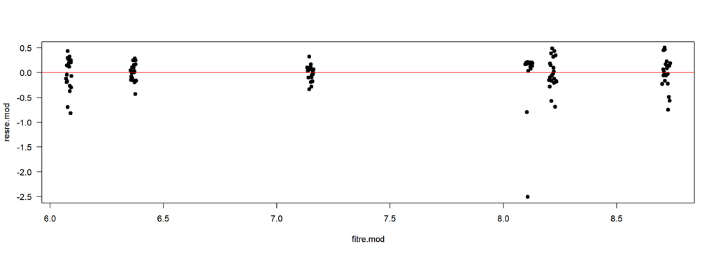

```r
# Plot the residuals as a function of the fitted data.
resre.mod <- resid(re.mod)
fitre.mod <- fitted(re.mod)
plot(resre.mod ~ fitre.mod, pch = 19, las = 1); abline(0, 0, col = "red")
```

#### **3. Include a figure of your data and model.**

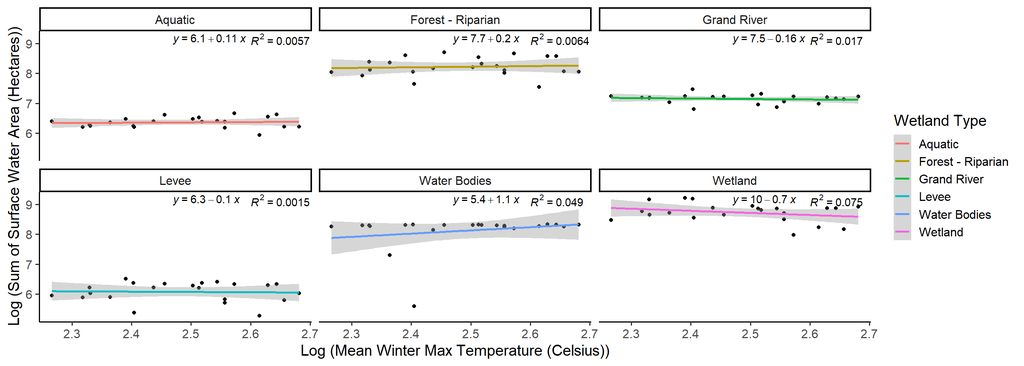

```r
library(ggplot2)
library(ggpubr)

# Look at the cover type specific plots to have a baseline of each cover type's SWA/tmmx_cels relationship.
ggplot(LGRW, aes(y = l.SWA_sum, x = l.tmmx_cels)) +
  geom_point() +
  xlab("Log (Mean Winter Max Temperature (Celsius))") +
  ylab("Log (Sum of Surface Water Area (Hectares))") +
  theme_classic(base_size = 15) +
  stat_smooth(aes(color = Cover_Type),
              method = "lm", formula = 'y ~ x', se = TRUE, fullrange = TRUE) +
  labs(color = "Wetland Type") +
  stat_regline_equation(label.x = 2.47, label.y = 9.15, aes(label = ..eq.label..)) +
  stat_regline_equation(label.x = 2.6, label.y = 9.15, aes(label = ..rr.label..)) +
  facet_wrap(~Cover_Type)
```